# Fifa 19

## by Abdelrahman Tarek Ahmed

## Preliminary Wrangling

### structure of my dataset:

> I started the cleaning with 18207 observations, 88 features. After i removed columns not needed for my analysis and also removes null values. There are 16,643 observations in the dataset with 45 features to work with. Changed the Value, Wage and Release Clause to int so we can make fearther analysis

### Main features of interest in my dataset:

- Age
- Nationality
- overall
- potential
- club
- value
- wage
- preferred Foot
- Work Rate
- Position
- Height
- Weight
- Release Clause

### Features in the dataset I think will help support my investigation into my feature(s) of interest :

- I expect player Age, Position and overall would have a huge effect on the players value
- I want to see if the Weight, Height and overall can determines player's Position
- I want to see if Nationality effect anything

## Univariate Exploration

> In this section, investigate distributions of individual variables. If you see unusual points or outliers, take a deeper look to clean things up and prepare yourself to look at relationships between variables.

## Numerical Variables:

### Age:

### remove players that are above 40 as they were only 4

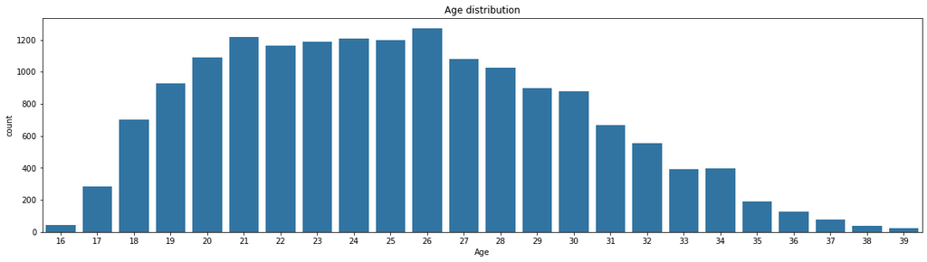

```python
base_color = sb.color_palette()[0]
plt.figure(figsize = [20, 5])
plt.title("Age distribution")
sb.countplot(data=df , x='Age', color=base_color);
```

> This distribution shows most of the players in our data are in their 20s. And it's slightly positive skewed.

### Height:

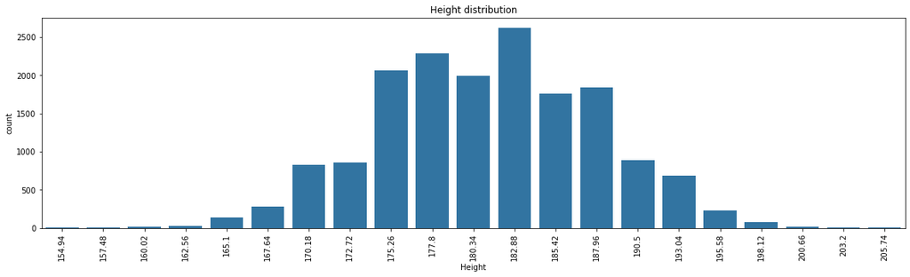

```python
df['Height'] = df['Height'].round(2)
plt.figure(figsize = [20, 5])

base_color = sb.color_palette()[0]
sb.countplot(data=df , x='Height', color=base_color);
plt.title("Height distribution")
plt.xticks(rotation=90) ;
```

> most players have height from 175cm to 188cm

### Weight:

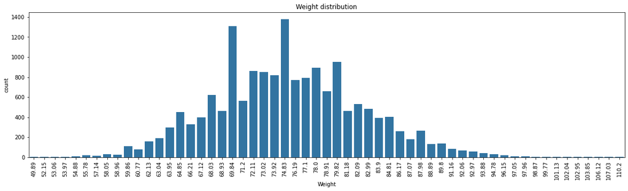

```python
df['Weight'] = df['Weight'].round(2)
plt.figure(figsize = [20, 5])
base_color = sb.color_palette()[0]
sb.countplot(data=df , x='Weight', color=base_color);
plt.title("Weight distribution")
plt.xticks(rotation=90) ;
```

### Overall:

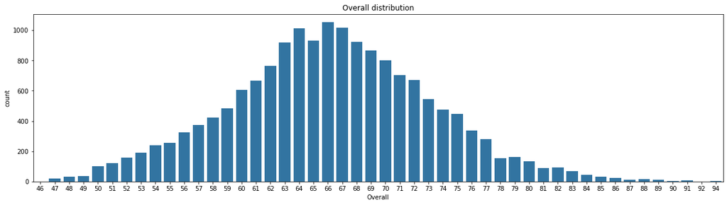

```python
plt.figure(figsize = [20, 5])
base_color = sb.color_palette()[0]
plt.title("Overall distribution")
sb.countplot(data=df , x='Overall', color=base_color);
```

> overall Rate is normally distributed

### Potential Rate

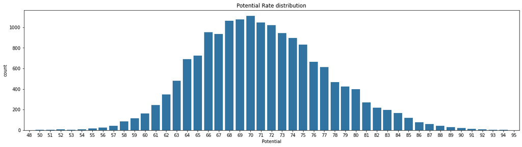

```python
plt.figure(figsize = [20, 5])
base_color = sb.color_palette()[0]
plt.title("Potential Rate distribution")
sb.countplot(data=df , x='Potential', color=base_color);
```

> Potential Rate is normally distributed

### Value :

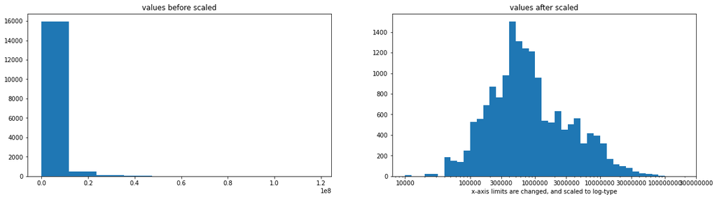

```python
plt.figure(figsize = [20,5])
plt.subplot(1, 2, 1)
plt.hist(data = df, x = 'Value')
plt.title("values before scaled")
plt.subplot(1,2,2)
ticks = [10000,100000, 300000,1000000,3000000,10000000,30000000,100000000,300000000]
labels = ['{}'.format(v) for v in ticks]
bins = 10 ** np.arange(4, 8+0.1, 0.1)
plt.hist(data=df, x='Value',bins = bins);
plt.title("values after scaled")
plt.xscale('log')
plt.xticks(ticks, labels);
plt.xlabel('x-axis limits are changed, and scaled to log-type');
```

```python
df[df['Value'] > 10000000]['Value'].count()/df['Value'].count() * 100
```

```
4.954304954304954
```

> changing the x-axis and found that only 5% of players have value more then 10M

### Wage:

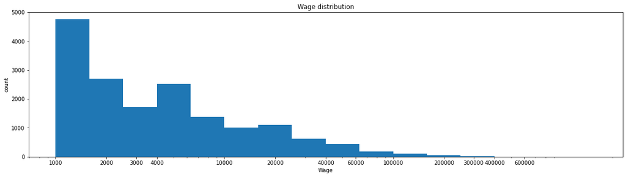

```python
plt.figure(figsize = [20, 5])
base_color = sb.color_palette()[0]
bins = 10 ** np.arange(3, 6.2+0.2, 0.2)

ticks = [1000, 2000, 3000, 4000, 10000, 20000, 40000, 60000, 100000, 200000, 300000, 400000,600000]
labels = ['{}'.format(v) for v in ticks]
plt.title('Wage distribution')
plt.xlabel('Wage');
plt.ylabel("count")

plt.hist(data=df , x='Wage', color=base_color,bins = bins);
plt.xscale('log')
plt.xticks(ticks, labels);
```

> only 1% have Wage more than One Hundred Thousand

### Release Clause:

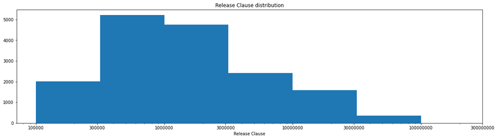

```python
plt.figure(figsize = [20, 5])
base_color = sb.color_palette()[0]

ticks = [100000, 300000,1000000,3000000,10000000,30000000,100000000,300000000]
labels = ['{}'.format(v) for v in ticks]
plt.title("Release Clause distribution")
bins = 10** np.arange(5,8+0.5,0.5)
plt.hist(data=df , x='Release Clause', color=base_color, bins = bins);
plt.xscale('log')
plt.xlabel('Release Clause');
plt.xticks(ticks, labels);
```

> only 2.6% have Release Clause more than 30M

## Categorical Variables:

### Work Rate

> Work Rates dictate where players position themselves on the pitch. it is the rate of a player’s behaviour on the pitch in terms of attacking and defensive works

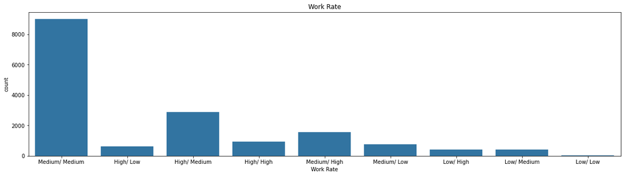

```python
plt.figure(figsize = [20, 5])
base_color = sb.color_palette()[0]
sb.countplot(data=df , x='Work Rate', color=base_color);
plt.title('Work Rate')
```

> Most of the players have Work Rate of Medium/Medium

### Preferred Foot:

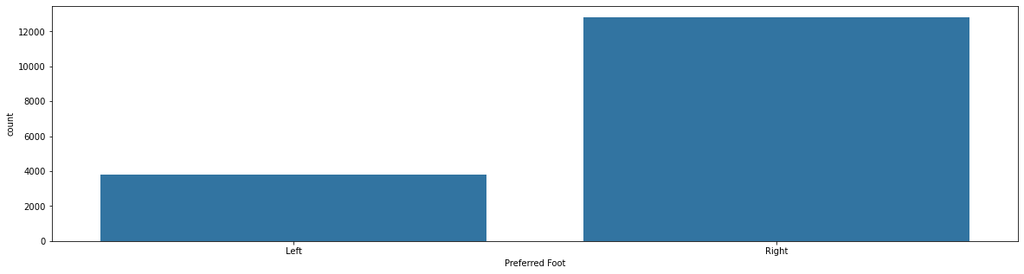

```python
plt.figure(figsize = [20, 5])
base_color = sb.color_palette()[0]
sb.countplot(data=df , x='Preferred Foot', color=base_color);
```

> Most of the players preffer Right Foot .

### Position:

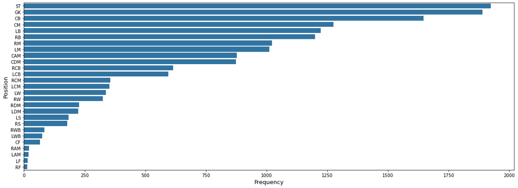

```python
ax = plt.subplots(1,1, figsize=(20,7))
base_color = sb.color_palette()[0]
sb.countplot(data = df, y = 'Position', color = base_color, order = position_count.index)
plt.ylabel('Position', color = 'black', fontsize = '13')
plt.xlabel('Frequency', color = 'black', fontsize = '13');
```

### Top 10 most country having clubs :

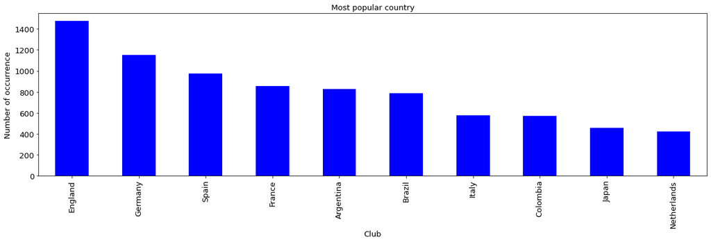

```python
nation = df.Nationality.value_counts()[0:10]
g_bar = nation.plot.bar(color = 'blue', fontsize = 13)

#figure size(width, height)
g_bar.figure.set_size_inches(20, 5);

#Add labels
plt.title('Most popular country', color = 'black', fontsize = '13')
plt.xlabel('Club', color = 'black', fontsize = '13')
plt.ylabel('Number of occurrence', color = 'black', fontsize = '13');
```

> Most players are from England

### Of the features you investigated, were there any unusual distributions? Did you perform any operations on the data to tidy, adjust, or change the form of the data? If so, why did you do this?

- we removed unnecessary columns such as photo, flag and so on
- checked for null and removed them
- fixed value, wage and release clause formats
- fixed Height and weight formats
- scale value, wage and release clause

## Bivariate Exploration

> In this section, investigate relationships between pairs of variables in your data. Make sure the variables that you cover here have been introduced in some fashion in the previous section (univariate exploration).

### Take a look at the correleations between variables

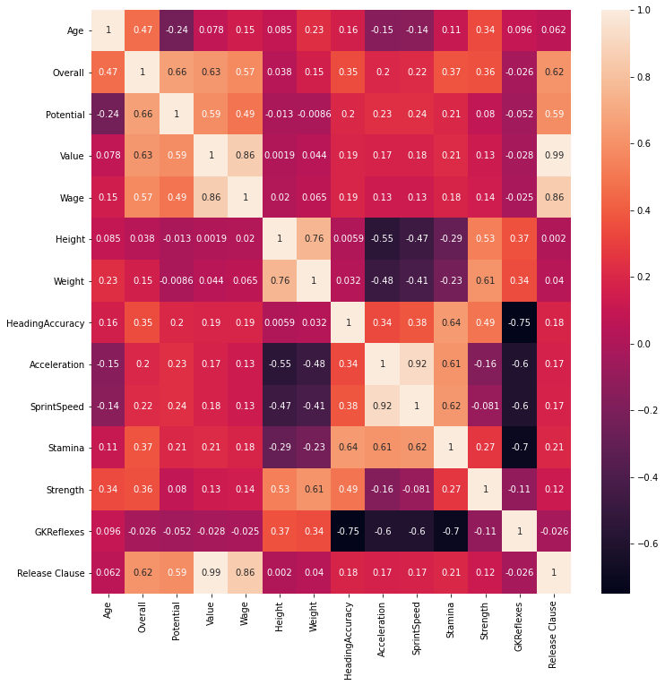

```python
hist = df[['Age', 'Overall', 'Potential', 'Value', 'Wage', 'Height', 'Weight', 'HeadingAccuracy',
                     'Acceleration','SprintSpeed','Stamina','Strength','GKReflexes','Release Clause',]]

# plotting heatmap
f, ax = plt.subplots(figsize=(12, 12))
corr = hist.corr()
sb.heatmap(corr,
            xticklabels=corr.columns.values,
            yticklabels=corr.columns.values,annot=True);
```

> We will take a look at features that have above 0.7 and some of the negative collerations

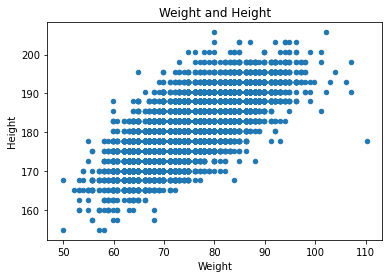

```python
#Weight and height
plt.figure(figsize = [20, 5])
df.plot(x='Weight', y='Height', kind='scatter', title = 'Weight and Height');
```

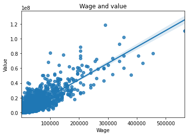

```python
#Correlation between Wage and Value
sb.regplot(data = df, x='Wage', y='Value');
plt.xlabel('Wage')
plt.ylabel('Value')
plt.title("Wage and value");
```

> A strong correlation between wage and value

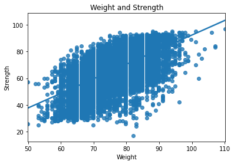

```python
#Correlation between weight and strength
sb.regplot(data = df, x='Weight', y='Strength');
plt.title("Weight and Strength")
plt.xlabel('Weight')
plt.ylabel('Strength');
```

> There is a strong correlation between Weight and Strength.

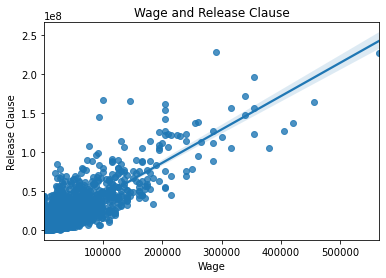

```python
#Correlation between Wage and Release Clause
sb.regplot(data = df, x='Wage', y='Release Clause');
plt.title("Wage and Release Clause")
plt.xlabel('Wage')
plt.ylabel('Release Clause');
```

> A strong correlation between Wage and Release Clause

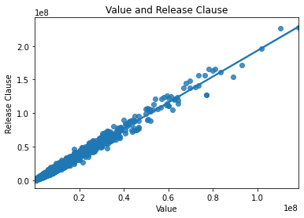

```python
#Correlation between Value and Release Clause
sb.regplot(data = df, x='Value', y='Release Clause');
plt.title("Value and Release Clause")
plt.xlabel('Value')
plt.ylabel('Release Clause');
```

> A strong correlation Between Value and Release Clause

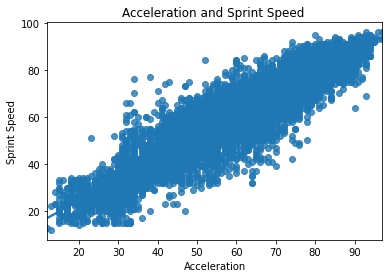

```python
#Correlation between Acceleration and SprintSpeed
sb.regplot(data = df, x='Acceleration', y='SprintSpeed');
plt.title("Acceleration and Sprint Speed ")
plt.xlabel('Acceleration')
plt.ylabel('Sprint Speed');
```

> A strong correlation between Acceleartion and sprint speed

### negative correlations

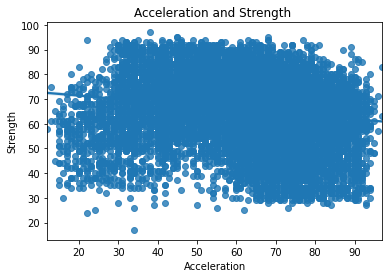

```python
#Correlation between Acceleration and Strength
sb.regplot(data = df, x='Acceleration', y='Strength');
plt.title("Acceleration and Strength ")
plt.xlabel('Acceleration')
plt.ylabel('Strength');
```

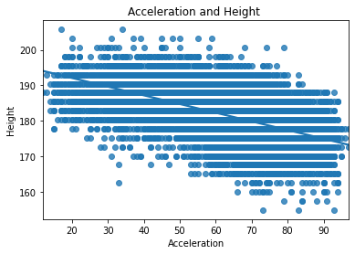

```python
#Correlation between Acceleration and Height
sb.regplot(data = df, x='Acceleration', y='Height');
plt.title("Acceleration and Height ")
plt.xlabel('Acceleration')
plt.ylabel('Height');
```

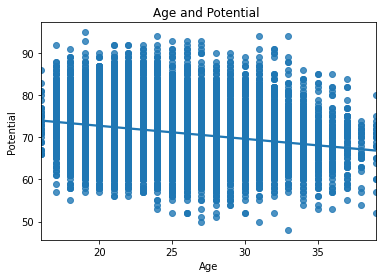

```python
#Correlation between Age and Potintial
sb.regplot(data = df, x='Age', y='Potential');
plt.title("Age and Potential ")
plt.xlabel('Age')
plt.ylabel('Potential');
```

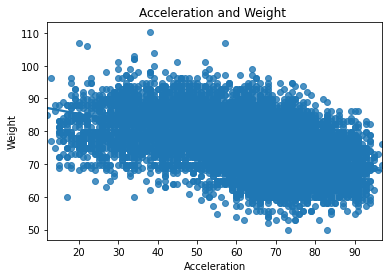

```python
#Correlation between Acceleration and Weight
sb.regplot(data = df, x='Acceleration', y='Weight');
plt.title("Acceleration and Weight ")
plt.xlabel('Acceleration')
plt.ylabel('Weight');
```

### Observations :

- Acceleration has a negative correlation with Weight, Height and Strength
- Value has postive correlation with Wage and release clause
- Wage has postive correlation with Value and release clause
- Weight has postive correleation with Strength and height

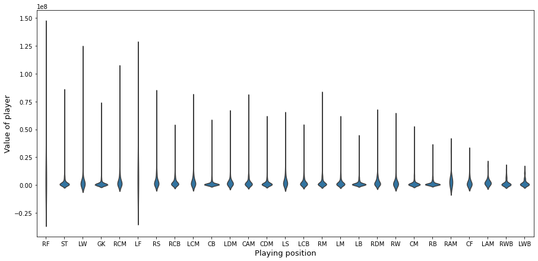

```python
# plotting violin plot
ax = plt.subplots(1,1, figsize=(15,7))

base_color = sb.color_palette()[0]
sb.violinplot(data = df, x = 'Position', y = 'Value',
             color = base_color, inner = None)
plt.ylabel('Value of player', color = 'black', fontsize = '13')
plt.xlabel('Playing position', color = 'black', fontsize = '13');
```

> Of all playing position, Right Forward players are valued more and have more variaty in values. Right wing back position and Left wing back position are valued lowest.

### Body Type vs Value:

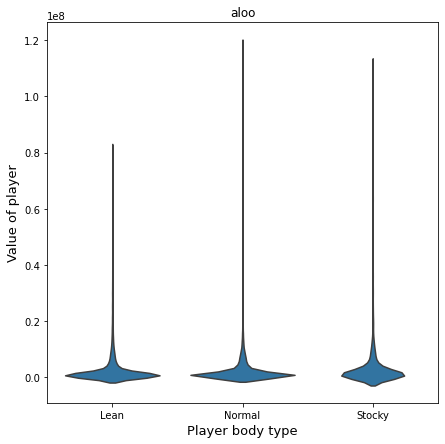

```python
# plotting violin plot
ax = plt.subplots(1,1, figsize=(7,7))

base_color = sb.color_palette()[0]
sb.violinplot(data = df, x = 'Body Type', y = 'Value',
             color = base_color,
              inner = None)
plt.ylabel('Value of player', color = 'black', fontsize = '13')
plt.xlabel('Player body type', color = 'black', fontsize = '13');
```

> This tells us that, players with normal body type are valued more.

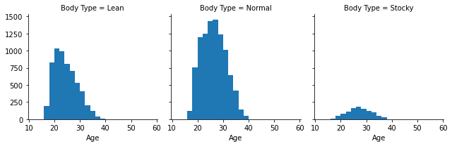

```python
# plotting Facet
bins = np.arange(12, 58+2, 2)
g = sb.FacetGrid(data = df, col = 'Body Type')
g.map(plt.hist, 'Age', bins = bins);
```

> This tells us the distribution of Age and the body type a player has. Most of our players in the data have a normal body type, and very few players have a stocky body type.

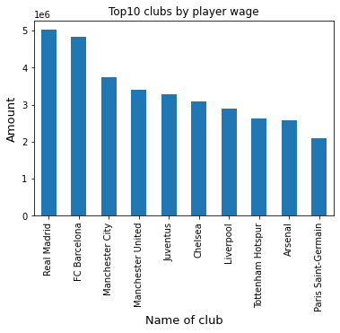

```python
# Group by club then sum the wage.
wages10 = df.groupby('Club')['Wage'].sum().sort_values(ascending = False).head(10)

# plot
wages10.plot.bar(title="Top10 clubs by player wage")
plt.ylabel('Amount', color = 'black', fontsize = '13')
plt.xlabel('Name of club', color = 'black', fontsize = '13');
```

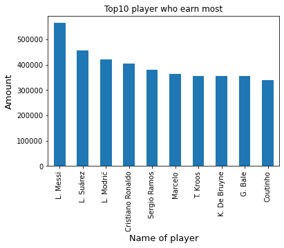

```python
 # Group by name then sum the wage.
p_wages10 = df.groupby('Name')['Wage'].sum().sort_values(ascending = False).head(10)

# plot
p_wages10.plot.bar(title="Top10 player who earn most")
plt.ylabel('Amount', color = 'black', fontsize = '13')
plt.xlabel('Name of player', color = 'black', fontsize = '13');
```

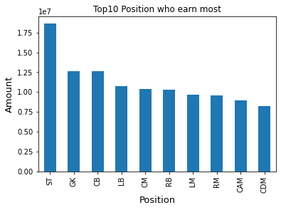

```python
 # Group by Position then sum the wage.
ps_wages10 = df.groupby('Position')['Wage'].sum().sort_values(ascending = False).head(10)

# plot
ps_wages10.plot.bar(title="Top10 Position who earn most")
plt.ylabel('Amount', color = 'black', fontsize = '13')
plt.xlabel('Position', color = 'black', fontsize = '13');
```

> Intersting, we found that ST earn more than the rest of all Positions

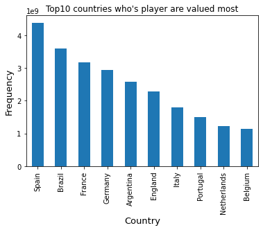

```python
# Group by nationality then sum the value.
p_nation = df.groupby('Nationality')['Value'].sum().sort_values(ascending = False).head(10)

# plot
p_nation.plot.bar(title="Top10 countries who's player are valued most")
plt.ylabel('Frequency', color = 'black', fontsize = '13')
plt.xlabel('Country', color = 'black', fontsize = '13');
```

> It seems that Spain have a high value players

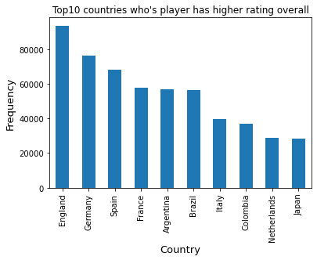

```python
# Group by nationality then sum the value.
p_overall = df.groupby('Nationality')['Overall'].sum().sort_values(ascending = False).head(10)

# plot
p_overall.plot.bar(title="Top10 countries who's player has higher rating overall")
plt.ylabel('Frequency', color = 'black', fontsize = '13')
plt.xlabel('Country', color = 'black', fontsize = '13');
```